# OP-SOCO210034 1795..1823

Converted from PDF `Jung-FinancializationCorporateDownsizing-2022-SER.pdf` · 29 pages · anchors: page `#pN`, block `#pN-bK`

Page 1

## Financialization and corporate downsizing as a shareholder value strategy

### Jiwook Jung * and Yin Lee

School of Labor and Employment Relations, University of Illinois at Urbana-Champaign, Champaign, IL, USA

*Correspondence: jwjung@illinois.edu

#### Abstract

How has financialization contributed to the changing nature of employment relations? Using the case of downsizing, we provide a cultural explanation of how the growing influence of the financial sector has reshaped employment relations at nonfinancial firms. We focus on the role of financial professionals in promoting the norm of shareholder value maximization around which financial market expecatations are formed and imposed upon firms. Our analysis of downsizing announcements made by the largest US firms shows that firms downsize when they miss earnings forecasts of securities analysts—a clear indication that firms fail to maximize shareholder value. We also show that institutional investors and financial executives promoted downsizing after missed analyst forecasts while labor unions resisted it. Despite the latter group’s resistance, in the context of the declining countervailing influence of labor, our findings suggest that downsizing has become institutionalized as a shareholder value strategy in the era of financialization.

Key words: financialization, employment relations, shareholder value, financial professionals, downsizing

JEL classification: J53, J63

#### 1. Introduction

The changing nature of employment relations and its consequences have recently received keen attention from scholars from various disciplinary backgrounds. Beginning in the late 1970s, a set of rules, norms and practices that governed employment relations at major US firms began to disintegrate (Appelbaum and Batt, 1994; Kochan et al., 1994; Cappelli, 1999; Osterman, 1999). In response, firms moved away from their reliance on internal labor markets toward more reliance on external ones (Bidwell, 2013; Cobb, 2015). The social and political implications of the shift have been enormous, reducing job security for workers

V C The Author(s) 2021. Published by Oxford University Press and the Society for the Advancement of Socio-Economics. All rights reserved. For permissions, please email: journals.permissions@oup.com

Socio-Economic Review, 2022, Vol. 20, No. 4, 1795–1823

doi: 10.1093/ser/mwab035

Advance Access Publication Date: 19 July 2021

Article

Page 2

in the middle and at the bottom while increasing the income gap between them and those at the top (Hacker, 2006; Kalleberg, 2009; Stiglitz, 2012). Previous studies have provided a variety of explanations for the shift toward employment relations based on external market mechanisms, including deregulation, technological change, globalization and foreign competition (Harrison and Bluestone, 1988; Baumol et al., 2003; Autor et al., 2008).

An emerging stream of research adds another important factor to the list—financialization, broadly defined as ‘the increasingly important role of financial markets, motives, actors and institutions in the operation of the economy’ (Fligstein and Goldstein, 2015, p. 575). Existing studies in the literature have offered two core mechanisms through which financialization can reshape employment relations. At the sectoral level, financial firms have gained economic power, leading to rent extraction from the economy as a whole. In turn, this has allowed financial firms and their employees to enjoy oversized rewards while reducing the share for non-financial firms and aggravating their labor relations (Tomaskovic-Devey and Lin, 2011; Godechot, 2012; Philippon and Reshef, 2012; Lin and Tomaskovic-Devey, 2013). At the firm level, non-financial firms have increasingly channeled resources into financial activities, rather than productive activities, to achieve higher rates of return for investors (Krippner, 2005; Orhangazi, 2008; Davis and Kim, 2015; Tori and Onaran, 2020). As firms have become more dependent on earnings generated from financial activities, they undermine labor’s bargaining power and constrain employment and wage growth (Alvarez, 2015; Tomaskovic-Devey et al., 2015; Lin, 2016). Altogether, these sectoral- and firm-level mechanisms offer a compelling explanation for how financialization has led to reduced job growth and unstable employment relations in the non-financial sector.

Nevertheless, one intriguing issue is the relationship between the sectoral- and firm-level mechanisms of financialization. Most prior studies treat one or the other mechanism separately without considering how sector-level processes reinforce firm-level outcomes or the other way around. In this article, we provide a cultural explanation that connects the dominance of the financial sector and changing employment relations at non-financial firms, focusing on the role of financial professionals in promoting the norm of shareholder value maximization around which financial market expecatations are formed and imposed upon firms. Studies on shareholder value suggest that the new norm of corporate governance has significantly undercut the bargaining power of workers as firms try to cut labor costs for the sake of shareholder value maximization (Fligstein and Shin, 2007; Jung, 2015). But how much profit should firms generate to meet the goal and, more importantly who decides the goal? In this respect, we highlight the role of securities analysts as a prominent group of financial professionals in the contemporary financial markets. We examine the impact of the firmly entrenched expectation in the US financial market that firms should meet quarterly earnings forecasts by securities analysts as a de facto indicator of shareholder value maximization (Dobbin and Zorn, 2005). We argue that downsizing has become an institutionalized practice to reassure the financial community when firms fail to satisfy the market expectations set by analyst forecasts.

Furthermore, we explore how other financial professionals have facilitated the process and whether workers have mounted any meaningful resistance. Scholars of financialization suggest that it is a fundamentally political project with the dominating role of finance within the economy and the concentration of wealth in the hands of financial interest groups (Tomaskovic-Devey and Lin, 2011; Godechot, 2012; Roberts and Kwon, 2017). Studies have also suggested that the rise of financialization has undermined the bargaining power of

1796 J. Jung and Y. Lee

Page 3

workers at the sectoral and national levels (Lin and Tomaskovic-Devey, 2013; Darcillon, 2015; Meyer, 2019). Few studies have examined how configurations of competing interest groups in and around the firm can shape the impact of financialization over distributional outcomes (Lin, 2016). As recent studies on shareholder value practices demonstrated (Fiss and Zajac, 2004; Jung, 2016; Carberry and Zajac, 2020), the effectiveness of external normative pressure depends crucially on firm-level constellations of power and interests. We examine the facilitating roles of two additional groups of financial professionals—institutional investors outside the firm and financial executives within the firm—as well as the countervailing influence of workers and their unions against the institutionalization of downsizing as a means to manage market expectations.

Using data on downsizing announcements made by the largest US firms from 1984 to 2006, our analysis shows that the rate of downsizing significantly increases soon after firms fail to meet or beat analyst forecasts. The increase is more pronounced for firms with large institutional ownership and those with chief financial officers (CFOs) but less so for firms within unionized sectors. These results hold even after we control for various firm-level measures of financialization, suggesting that employment decisions by firms are influenced not just by firm-level financialization but also by extra-firm influences stemming from financial markets. By elaborating how financialization affects firm-level decisions on employment practices, our study also demonstrates the merit of combining insights from the financialization and shareholder value literatures. Such an approach, we believe, will extend our understanding of how the broad economy-wide turn to financialization reshapes firm-level distribution of power and resources.

#### 2. Financialization and changing employment relations

Over the past decades, employment relations at US firms have undergone significant changes (Osterman, 1999). Among many possible causes of the changes, financialization has received growing attention. Financialization is often defined as ‘the pattern of accumulation in which profits accrue primarily through financial channels rather than through trade and economy’ (Krippner, 2005, p. 174). It is manifested into two interrelated, multilevel processes. The first process, which occurs at the sectoral level, is the increased importance of finance in the economy (Tomaskovic-Devey and Lin, 2011). It is well documented that wealth accumulation has been disproportionately concentrated in the financial sector since the late 1970s as a result of deregulation and global competition (Van der Zwan, 2014; Lin, 2016). For instance, Krippner (2005) and Tomaskovic-Devey and Lin (2011) show that the proportion of financial sector profits out of total profits in the US economy has steadily increased since the 1980s, and was further accelerated by a dramatic uptake in the 2000s. Kaplan and Rauh (2010) also show that Wall Street’s (e.g. investment bankers and hedgefund investors) representation at the top end of the income distrubution surpassed that of the Main Street (e.g. non-financial firm top executives).

The second process, which occurs at the firm level, is the increased importance of financial activities in non-financial firms’ bottom line (Krippner, 2005; Van der Zwan, 2014). In those firms, primary profit-generating activities have shifted from investing in production and service activities to engaging in financial activities (Lin, 2016; Tori and Onaran, 2020). For instance, Orhangazi (2008) shows that there is a negative relationship between real investment and financialization in non-financial firms. This suggests that the increase in financial activities can disincentivize managers from engaging in real investments that might yield

Financialization and corporate downsizing 1797

Page 4

lower profits than the financial investments, and that payments to financial markets (i.e. dividends and share buybacks) can reduce the internal resources that can be allocated to real investments (Orhangazi, 2008).

These two interrelated processes of financialization can have a significant impact on employment relations. By diverting resources toward financial activities, financialization can reduce the resources that can be used for productive activities and additional employment. Using industry-level data from the USA, Lin and Tomaskovic-Devey (2013) show that increased reliance on financial income in the non-financial sector was associated with a decrease in workers’ share of income in addition to rising income inequality between executives and non-executive workers and among workers themselves. Using country-level data for 21 Organization for Economic Co-operation and Development (OCED) member countries, Meyer (2019) also shows that equity market development weakens the institutional foundations of labor unions’ bargaining power, such as wage bargaining coordination and centralization. Based on firm-level data on financialization and employment, Lin (2016) suggests that the increased financial activities at non-financial firms can lead to employment stagnation. His analysis shows that firms that make more financial investments, rely more on debt and provide shareholders with more rewards through stock repurchases and dividends have lower levels of employment growth.

To sum up, the existing literature on financialization convincingly demonstrates the sectoral-level shift in the distribution of economic resources and the corresponding redistribution of resources at the firm level. One issue that requires more research is the mechanisms that link the two processes at sectoral and firm levels. For instance, why do non-financial firms acquiesce to the increasingly commanding role of the financial sector? What are the mechanisms through which the financial sector binds non-financial firms to act in its interests? Relatedly, how does the growing influence of finance reshape firm-level configurations of competing stakeholder groups—such as managers, shareholders and workers—and their ability to promote or resist firm-level financialization?

Building on insights from the shareholder value literature, we examine how the norm of shareholder value maximization leverages the finance sector’s influence over non-financial firms and facilitates the diversion of resources away from productive activities, and how several groups of financial professionals lead the charge. It is important to elaborate such mechanisms that link the rise of the shareholder value model of the firm and changing employment relations, because despite the consensus on the normative grip of the new governance model, the debate continues about whether the model has fundamentally reshaped corporate decisions and practices (Shin, 2013). Firms may merely symbolically embrace the model, adopting a set of shareholder value practices without implementing them (Westphal and Zajac, 2001; Zajac and Westphal, 2004). Managers may even resist the model and related practices and even use them to advance their interests, not those of shareholders (Goldstein, 2012; Benton 2016; Pernell et al., 2017). In the following, we offer a mechanism of financial market control through the role of securities analysts.

#### 3. Securities analysts and the institutionalization of downsizing as a means to manage market expectations

The central tenet of the shareholder value model of the firm is that the sole goal of corporations is to maximize returns to shareholders (Fligstein and Shin, 2007). But how do firms

1798 J. Jung and Y. Lee

Page 5

know whether or not they manage to maximize shareholders’ wealth? Enter securities analysts. Through their quarterly earnings forecasts for firms (analyst forecasts, henceforth), they not only channel but also actively shape financial market expectations for firms against which their commitment to shareholder value maximization is assessed (Dobbin and Zorn, 2005). The original purpose of these forecasts was to assist investors in making informed investment decisions, but analyst forecasts soon became the de facto performance target that could not be missed (Collingwood, 2001). The prominence of analyst forecasts sharply divides acceptable from unacceptable performance. Much financial and accounting research has demonstrated that stock prices now rise and fall on the strength of profits vis-a`-vis analyst forecasts (Bartov et al., 2002). The magnitude of market reactions, which includes rewards for meeting analyst forecasts and penalties for failure, has increased over time (Lopez and Rees, 2002). The possibility of harsh penalties for missing analyst forecasts induces firms to proactively manage their earnings to avoid earnings surprises. It is well known that managers engage in various earnings management practices for that purpose (Degeorge et al., 1999; Bergstresser and Philippon, 2006; Zhang et al., 2008). Managers can also influence analyst forecasts, by issuing their own forecast guidance and making conference calls with analysts (Washburn and Bromiley, 2014).

Such strategic engagement by firms, however, may not diminish the importance of meeting analyst forecasts. It can reinforce the institutional standing of the practice (Mazmanian and Beckman, 2018). Sauder and Espeland (2009, p. 76) explain this ironic outcome using the concept of gaming, defined as ‘cynical efforts to manipulate the rankings data without addressing the underlying condition that is the target of measurement’. They argue that although gaming can challenge the legitimacy of rankings through cynicism, distancing and localized resistance, it helps solidify their legitimacy by increasing the amount of effort and investment that organizations put into to enhance their rankings. Similarly, firms’ active involvement in the construction of their own earnings forecasts can make it even more important for them not to miss analyst forecasts.

The institutionalized expectation that firms should meet or beat quarterly earnings projections of securities analysts pushes firms to adopt drastic reforms when they fail so as to regain investor confidence (Puffer and Weintrop, 1991; Zuckerman, 2000; Zhang and Gimeno, 2010; Benner and Ranganathan, 2012). For instance, in a series of studies, Zuckerman (1999, 2000) illustrates how securities analysts advanced the norm against excessive corporate diversification and penalized firms that did not conform. In the 1980s, diversification was identified as the main example of managerial opportunism that would reduce shareholder wealth (Amihud and Lev, 1981; Jensen, 1986). This view was against the financial orthodoxy that insisted that investors, not firms, should diversify. Moreover, diversified firms performed poorly compared with focused firms (Berger and Ofek, 1995). Zuckerman (1999, 2000) shows that diversified firms suffered from low valuation because, compared with focused firms, securities analysts who specialized by industry paid them less attention, and therefore, those firms faced pressure to de-diversify and focus on their core competencies.

We suggest that when firms fail to meet analyst forecasts, they will announce downsizing plans to signal their willingness to compensate for their failure and to reassure analysts and investors. Firms increasingly engaged in downsizing in the 1980s and 1990s under pressure to maximize shareholder value (Fligstein and Shin, 2007; Lazonick and O’Sullivan, 2000; Jung, 2015). Once considered a rarity among large US firms except during economic

Financialization and corporate downsizing 1799

Page 6

downturns, workforce downsizing became an accepted business practice (Budros, 1997). Previously, firms temporarily laid off workers during business downturns with a promise of recall when economic conditions improved; since the 1980s, layoffs predominantly meant permanent termination of employment ties (Osterman, 1999). Firms dismissed large numbers of employees even when times were good (Cappelli, 1999; Osterman, 1999). Fortune 500 companies such as Kodak and Xerox made massive layoffs even as they reported record profits in the 1990s. One possible reason is that even seemingly well-performing firms may not live up to the financial market expectations indicated by securities analysts’ earnings forecasts.

In fact, when announcing downsizing plans, firms often describe their performance vis-a`- vis analyst forecasts, sometimes even explicitly mentioning that the move is intended to compensate for their failure to meet forecasts. In May 2006, when announcing a plan to cut 4000–5000 jobs, Jonathan Schwartz, the newly appointed CEO of Sun Microsystems, noted that the expected cost savings from the job cuts would help the company meet analyst forecasts of a loss of 2 cents a share (Flynn, 2006). In other cases, even good performers that barely missed analyst forecasts tried to appease the market by initiating downsizing. In July 2005, Abbott Laboratories, a healthcare company, posted a 38% gain in second-quarter profits compared with the same quarter the previous year but predicted that earnings in the next quarter would fall short of analyst forecasts. Its stock price fell immediately, and, in a bid to quell the market, the company announced a plan to cut 700 jobs (Colias, 2005).

Hypothesis 1 (H1): Missing quarterly earnings forecasts by securities analysts will increase the likelihood that firms will make downsizing announcements in the next fiscal quarter.

#### 4. The role of other financial professionals and the countervailing influence of labor

The increased influence of finance over non-financial firms is also likely to reshape power relations within those firms over the distribution of resources (Tomaskovic-Devey and Avent- Holt, 2019). We suggest that the changed configurations of group interest and power have also contributed to the institutionalization of downsizing as a shareholder value strategy. On the one hand, we examine the role of other ascending groups of financial professionals inside and outside the firm, such as institutional investors in capital markets and financial executives within the top management team. Their influence is likely to push firms to engage in downsizing when they fail to keep up with financial market expectations. On the other hand, we examine the countervailing influence of workers and their unions. From the perspective of workers, downsizing can be seen as a tool of rent transfer from workers to shareholders and top managers (Sørensen, 2000; Dencker, 2012). Hence, the collective voice of workers through labor unions will discourage firms from engaging in downsizing even after missing analyst forecasts. While all of these competing groups may attempt to influence corporate downsizing decisions to their advantage, we argue that the declining political power of workers allows firms to engage in downsizing to satisfy the demand of financial community.

4.1 External promotion by institutional investors Institutional investors are the first group who has both the incentive and the power to promote downsizing to compensate for missing analyst forecasts. Their increased ownership of

1800 J. Jung and Y. Lee

Page 7

and activism against US corporations have been the main drivers for the shareholder value model of the firm (Davis and Thompson, 1994; Useem, 1996; Dobbin and Jung, 2010). As they are paid based on the performance of the funds they manage, it is in their interest to maximize the share prices of firms in their portfolios. Hence, their presence is likely to increase the need for compensatory action when a firm misses the performance target set by securities analysts—a clear indication that the firm has failed to maximize shareholder value. Institutional investors include several different types and have different investment strategies depending on the size of their holdings and investment time horizons (Bushee, 1998). Accordingly, their tactics to pressure management also differ. For instance, institutions with large holdings tend to have a long-term time horizon, and therefore they likely turn to ‘voice’ strategies, directly challenging management through anti-management resolutions and private negotiation (Carleton et al., 1998; Gillan and Starks, 2000). In contrast, institutions with small holdings tend to have a short-term time horizon, and therefore they prefer ‘exit’ strategies by selling under-performing stocks (Parrino et al., 2003).

Either way, their presence will put firms under significant pressure when they miss analyst forecasts. Stock price declines after earnings surprises can increase the risk that the firm will become a target of shareholder activism in the future (Del Guercio and Hawkins, 1999). Also, sell-offs by mobile investors can further depress the stock price of the firm. We expect that in order to avoid either direct challenge from activist institutional investors or massive sell-offs by passive ones, a firm is more likely to engage in downsizing after missing analyst forecasts when a sizable portion of its stock is owned by institutional investors.

Hypothesis 2 (H2): Institutional ownership will increase the likelihood of downsizing announcements after missed analyst forecasts.

4.2 Internal promotion by CFOs While the influence of institutional investors and securities analysts can increase external pressure upon firms that miss analyst forecasts, the presence of internal actors who embrace their concerns and preferences can enhance the receptivity of firms to such pressure. Financial experts within the top management team can play such a role. In this respect, we emphasize the role of CFOs. Unlike treasurers or controllers whose tasks are mostly confined to bookkeeping, they are actively involved in handling investor relations and communicating with analysts, by issuing regular reports, holding conference calls and issuing earnings preannouncements (Zorn, 2004). Meeting future earnings projections of securities analysts are crucial for CFOs to maintain their credibility with investors and analysts and sustain the firm’s stock market performance (Graham et al., 2005). Also, as a member of the top management team, CFOs have a critical say in corporate decision-making including downsizing decisions (Jung, 2015). Therefore, we expect that firms with a CFO are more likely to initiate downsizing after they miss analyst forecasts to avoid the same failure in the future.

Hypothesis 3 (H3): The presence of a CFO will increase the likelihood of downsizing announcements after firms miss analyst forecasts.

4.3 Countervailing but declining influence of labor unions Lastly, we examine the role of labor unions as a countervailing force against the influence of investors and analysts over corporate downsizing decisions. Recent studies show that,

Financialization and corporate downsizing 1801

Page 8

despite the declining membership and political influence of labor unions over the last three decades, unionized workers maintain a certain level of bargaining power and mobilizing capacity (Rosenfeld, 2006; Martin and Dixon, 2010). Workers in unionized sectors have greater job security, stable pension benefits and a lower-income gap between them and executives (Bidwell, 2013; Shin, 2014; Cobb, 2015). These studies suggest that labor unions can act as a countervailing force when firms make downsizing decisions through bargaining about layoff terms or threats of strikes; although labor unions eventually failed to stop the wide spread of downsizing, they often exerted influence over how firms implemented downsizing (Jung, 2016). Possible resistance from workers can make firms cautious when making downsizing decisions even when they are under pressure from investors and analysts. At least, they may delay the timing of announcements to avoid confrontation with workers and labor unions. Hence, we expect that firms in unionized sectors are less likely to engage in downsizing even after missing analyst forecasts.

Hypothesis 4 (H4): Industry-level union membership will decrease the likelihood of downsizing announcements after missed analyst forecasts.

#### 5. Data and methods

1 In most cases (16 of 23 industries), sampling was done exclusively from the Fortune Industrial 500. For the remaining industries (communications, utilities, transportation, wholesale and retail, service, health care and entertainment), sampling was done using specialized Fortune lists until Fortune Industrial 500 and other specialized lists were combined to become Fortune 500 in 1994. Supplementary Appendix A presents the number of sampled firms by industry. 2 Excluding these industries does not substantively change our results.

1802 J. Jung and Y. Lee

Page 9

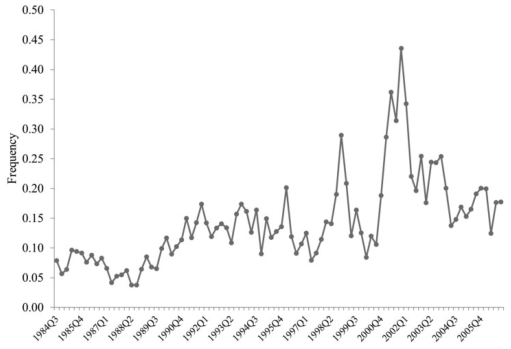

NOTE: figure/graphic rendered as an image from the PDF; its content is not machine-readable text. Caption (if any) follows as the next block.

Failure to meet analyst forecasts. A binary variable was coded as one if a firm’s reported quarterly earnings per share (EPS) were less than the consensus forecast of securities analysts

Figure 1. Downsizing announcements.

3 While our approach maximizes the coverage of downsizing announcements ever made public by sampled firms, there can be an issue of heterogeneity among events. We conduct a robustness check using downsizing announcements involving more than 1% of the firm’s workforce. The results, presented in Supplementary Appendix B, show that using the 1% cutoff point does not substantively change our main findings in Table 2.

Financialization and corporate downsizing 1803

Page 10

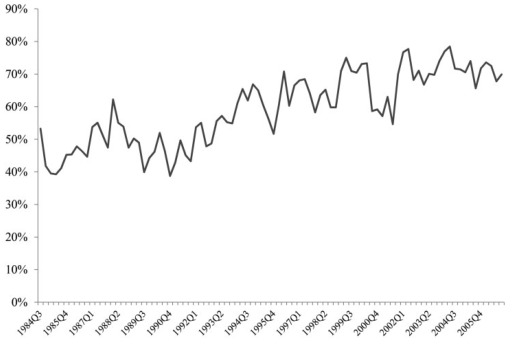

NOTE: figure/graphic rendered as an image from the PDF; its content is not machine-readable text. Caption (if any) follows as the next block.

covering the firm. The consensus forecast was calculated as the mean of all forecasts made by securities analysts before the actual announcement of quarterly earnings. The consensus is available in real time to investors and executives, and failure to meet the consensus forecast is often reported in the business press. The data came from the I/B/E/S database that collects earnings estimates from more than 200 brokerage houses and 2000 individual analysts. In addition to the binary variable, the reported quarterly EPS was also included. If the binary variable was merely a coarse measure of performance (i.e. earnings), then its effect should become negligible when actual EPS are included. Figure 2 shows that the percentage of firms that meet or beat analyst forecasts increased during our observation period.

Moderating variables. We measured institutional ownership as the percentage of a firm’s stock held by all types of institutional investors, using data from Thomson Financial. We identified firms with a CFO from each year’s edition of Standard & Poor’s Register of Corporations, Directors, and Executives.<sup>4</sup> For industry-level labor union density, we used a database built by Hirsch and Macpherson (2003).<sup>5</sup> Firm-level measures of unionization would be preferable, but without reliable data sources, previous studies showed that industry-level unionization can be a decent proxy for firm-level worker influence (Leicht, 1989; Shin, 2014; Jung, 2016). When firms have operations in multiple industries, we calculated a weighted average using the proportion of sales from each industry as their weight.

Control variables. We controlled for a set of variables that can affect a firm’s decision to downsize. Most variables vary quarterly, but others vary annually because quarterly data are not available. In either case, all variables were lagged so that they reflect the state in the

Figure 2. Firms meeting or beating analyst forecasts.

4 Almost all firms in our sample had a CFO by the end of our observation period because the Sarbanes-Oxley Act of 2002 required both the CEO and the CFO to certify all financial statements filed with the SEC. 5 Available at http://www.unionstats.com.

1804 J. Jung and Y. Lee

Page 11

Table 1. Summary statistics and bivariate correlations

Variables Mean SD 1 2 3 4 5 6 7 8 9 10

1. Downsizing announcements 0.116 0.320 2. Failure to meet analyst forecasts 0.418 0.493 0.042 3. Institutional ownership 56.805 19.102 0.051 –0.125

4. CFOs 0.690 0.462 0.073 –0.090 0.218 5. Industry labor union coverage 20.202 14.219 0.017 0.095 –0.239 –0.125

6. Revenue from financial divisions 0.008 0.072 –0.010 –0.036 0.052 0.020 –0.103

7. Debt ratio 0.598 0.169 0.070 –0.006 0.009 0.154 0.193 0.003 8. Shareholder rewards 0.330 0.894 0.105 –0.067 –0.045 0.043 –0.020 –0.009 0.003 9. Securities analysts 9.556 5.942 0.126 –0.105 0.227 0.160 –0.141 0.043 –0.110 0.400 10. Dispersion in analyst forecasts 0.043 0.089 0.032 0.093 –0.065 –0.041 0.151 –0.023 0.197 –0.027 –0.082

11. Earnings management 0.066 0.114 0.018 –0.032 0.103 0.058 –0.122 0.024 0.032 0.021 0.075 –0.002

12. Outside directors 77.397 12.523 0.089 –0.063 0.205 0.178 0.090 0.015 0.183 0.104 0.158 0.015 13. Return on assets 0.973 2.160 –0.054 –0.094 0.031 –0.014 –0.106 0.022 –0.251 0.081 0.122 –0.151

14. Cumulative stock returns 0.037 0.194 –0.067 –0.153 –0.006 –0.006 –0.008 0.023 –0.021 –0.016 –0.017 –0.034

15. EPS 0.362 1.340 0.001 –0.097 0.035 0.008 –0.003 0.006 –0.031 0.055 0.022 0.278 16. Net investment in fixed assets 4.084 1.336 0.010 –0.012 –0.081 0.048 0.408 –0.072 0.172 0.199 0.184 0.062 17. Total assets 8.038 1.368 0.202 –0.080 0.158 0.204 0.176 0.004 0.229 0.503 0.604 0.031 18. Diversification 0.456 0.474 0.068 0.032 0.018 –0.008 –0.008 –0.017 0.053 0.023 –0.028 0.051 19. Acquisition announcements 0.023 0.153 0.026 –0.007 0.025 0.002 –0.018 –0.001 –0.010 0.000 0.002 –0.016

20. Divestiture announcements 0.176 0.554 0.075 0.003 0.011 0.061 0.003 –0.002 0.087 0.154 0.126 0.021 21. Sales growth rate 1.154 16.109 –0.014 –0.030 0.013 –0.008 –0.017 0.015 –0.018 –0.009 0.017 –0.014

22. Industry growth rate 8.371 24.930 –0.029 –0.023 –0.007 –0.019 –0.024 –0.002 –0.026 –0.012 –0.001 –0.017

23. Downsizing density 0.480 0.384 0.134 –0.080 0.235 0.217 0.020 –0.045 0.114 0.077 0.150 –0.026

Variables 11 12 13 14 15 16 17 18 19 20 21 22 12. Outside directors –0.001

13. Return on assets –0.012 –0.065

continued

Page 12

Table 1. Continued

Variables Mean SD 1 2 3 4 5 6 7 8 9 10

14. Cumulative stock returns 0.006 –0.020 0.051 15. EPS –0.022 0.036 0.126 0.021 16. Net investment in fixed assets –0.087 0.188 –0.091 –0.011 0.027 17. Total assets –0.004 0.318 –0.048 –0.038 0.062 0.464 18. Diversification –0.050 0.073 –0.024 –0.006 0.065 –0.070 0.155 19. Acquisition announcements 0.029 –0.001 –0.002 0.014 0.002 0.001 –0.001 –0.001

20. Divestiture announcements 0.004 0.057 –0.047 0.012 0.017 0.065 0.229 0.130 0.036 21. Sales growth rate 0.016 –0.016 0.091 0.017 0.029 0.002 –0.001 –0.017 0.023 0.000 22. Industry growth rate 0.005 –0.025 0.047 0.018 0.003 –0.023 –0.035 –0.018 –0.003 –0.013 0.057 23. Downsizing density 0.089 0.155 –0.086 –0.030 –0.021 0.002 0.189 0.064 0.003 0.045 –0.012 –0.079

Page 13

previous quarter or year. Table 1 presents descriptive statistics and bivariate correlations. Unless otherwise identified, the primary data source is Compustat.

First, we controlled for a set of firm-level measures of financialization that have been widely used in previous studies—firms’ dependence on financial activities, debt financing and rewards to shareholders. These firm-level measures of financialization are shown to be negatively associated with firm-level job growth (Davis, 2016; Lin, 2016). That does not mean that firm-level financialization will be directly related to downsizing decisions. We included these measures for comparison with previous studies using those measures and also because downsizing can be one factor behind reduced job growth at the firm level. For firms’ dependence on financial activities, most previous studies tried to measure the size of a firm’s financial assets, such as stocks and bonds. We did not adopt a similar measure because of a severe missing data problem. Instead, we used the proportion of revenue from the firm’s financial business over total revenue. We gathered the data on revenue streams from different divisions using Compustat’s segment database. We measured firms’ dependence on debt as the ratio of the firm’s total leverage over total assets. Finally, we measured rewards to shareholders as the sum of stock buybacks and dividends.

We then added a set of analyst-related variables to account for the possibility that the effect of missing analyst forecasts may capture some other aspects of dynamics between analysts and firms. We included analyst coverage, measured as the number of securities analysts that covered the focal firm at least once during the given fiscal quarter, using data from the I/ B/E/S database. We also included the accuracy of analyst forecasts, measured as the standard deviation in forecasts because pressure from missing the consensus forecast would be weaker when there is large variability among analysts’ expectations.<sup>6</sup> Lastly, we added a measure of corporate earnings management. Firms actively manage their earnings numbers in order to shape analyst expectations, which may in turn affect their ability to meet those expectations and the amount of pressure they may feel when they fail. We used an accruals-based measure of earnings management, which is widely adopted in the accounting literature (Dechow et al., 1995).

We included a measure of board independence as a measure of board monitoring. Boards dominated by outside directors are more sensitive to external pressure for better performance (Mizruchi, 1983). We measured board independence as the percentage of outside directors on the board who were not current employees of the firm. We identified outside directors using Standard & Poor’s Register. We included several measures of firm performance because firms often engage in downsizing in response to poor performance (Budros, 1997). Return on assets is a widely used measure of operating performance. Cumulative stock returns, which indicate the percentage change in stock prices over the previous 12 months, measure a firm’s stock performance. Data on stock returns are from the Center for Research in Security Prices (CRSP) database. As we have explained above, we also added reported quarterly EPS. Technological innovation can lead to downsizing because new technology can reduce the need for human labor (Baumol et al., 2003). We added net investment in fixed assets as a proxy for technological upgrading. This variable may also account for the labor intensity of the firm’s business, which can discourage downsizing. Firm size also

6 In fact, in a test not reported in the article, we found out that the effect of missing analyst forecasts becomes smaller, although remaining statistically significant, at high levels of forecast dispersion.

Financialization and corporate downsizing 1807

Page 14

matters because larger firms may have more slack to reduce (Love and Nohria, 2005). We added total assets as a measure of firm size.

Because downsizing often follows merger and acquisitions, we included the count of the number of acquisitions completed by the focal firm in the previous quarter. Other types of restructuring may precede or occur simultaneously with downsizing. Data on acquisitions and divestitures are from Securities Data Company (SDC) Platinum. We included counts of the number of asset divestitures in the previous quarter. We also controlled for the level of diversification using the entropy index (Palepu, 1985). Focused firms are more likely to downsize to reduce redundancies. The index uses information from Compustat’s segment database. Growth-oriented firms or firms in growing industries are less likely to downsize. We added revenue growth at the firm and the industry level. Firms engage in downsizing more frequently during economic downturns. To account for the possibility that firms engage in downsizing following other similar firms, we measured the density of downsizing announcements as the percentage of other firms within the focal firm’s industry (excluding the focal firm) that made a downsizing announcement in the previous 12 months. Finally, in order to account for any unmeasured secular trends, we included fiscal-quarter dummies with the third quarter of 1984 omitted as a baseline.

We used a Cox regression model to estimate the rate of downsizing announcements. It is a semi-parametric model; unlike other parametric models that assume functional forms of the time dependency of the baseline rate of event occurrence, the Cox model lets the data to determine the shape of the baseline rate (Allison, 1995). This feature of the model is advantageous for our purpose because without knowing the baseline rate of downsizing announcements, any choice of the functional form for the baseline rate function can be arbitrary. We used the Efron method for tied events.

Because most firms in our sample made more than one downsizing announcement during the observation period, the repeatability of our event requires special attention. To address this problem, we use a fixed-effects Cox regression model (Allison, 2005). It is a Cox

7 Because this procedure can generate biased estimates, we conduct a robustness check by estimating models without left-truncated spells. We re-estimated our models after removing left-truncated event spells. The results, provided in Supplementary Appendix C, are very similar to our findings in Table 2, except that a few interaction effects become insignificant.

1808 J. Jung and Y. Lee

Page 15

model with stratification on firms; hence, event spells from the same firm share the same baseline rate of downsizing announcements. Hence, announcement spells from a firm share the same baseline hazard function. Like any other fixed-effects models, our fixedeffects Cox model accounts for all time-invariant covariates, such as industry, which allow us to make stronger causal claims. One downside is that it drops firms with no events (those with only a single right-censored event spell) as well as firms with one uncensored spell and one right-censored spell if the latter is shorter than the former (Allison, 2005, p. 116). This is why the number of firms and events used for our analysis is smaller than the size of our sample.<sup>8</sup>

Covariates are updated on a quarterly basis whenever possible. To do so, we split each event spell into quarterly intervals. Each quarterly interval starts at the date of the quarterly earnings report and ends immediately before the next quarterly earnings report.<sup>9</sup> This way of defining quarterly intervals ensures that we capture the sensitivity of downsizing announcements to the most recent earnings announcements. Specifically, at each date of a firm’s quarterly earnings announcement, we recorded whether the firm had met or beat the consensus analyst forecast and updated information on covariates. If no announcement was made until the next quarterly earnings report, we started a new quarterly interval and repeated the same process. If an announcement occurred within the interval, we closed the event spell at the point, reset the time to zero and started another event spell. We continued this process until the end of the observation period (the last fiscal quarter of 2006) or until the firm dropped out of the risk set.<sup>10</sup>

Finally, to enhance our causal claim about the effect of missing analyst forecasts, we conducted a robustness check using a regression discontinuity (RD) design. This quasiexperimental design has been primarily applied to continuous outcomes, but it is generalizable to other types of outcomes including time-to-event outcomes (Bor et al., 2014). It utilizes a cutoff point or threshold in the assignment of treatment status (Angrist and Pischke, 2009). In our case, the treatment status (i.e. failure to meet analyst forecasts) is assigned to firms when the assignment variable (quarterly EPS) is less than the threshold (securities analysts’ forecasts) even by 1 penny. When we limit our data to a very narrow range around the threshold, the difference between firms that meet and fail to meet analyst forecasts will become slim. Although our firm fixed-effects models account for all time-invariant firm-specific characteristics, there can be unobserved time-varying covariates that can affect both a firm’s downsizing decision and its ability to meet analyst forecasts. Our robustness check using an RD design reduces the possibility that such unobserved variables drive our main findings.

#### 6. Results

Table 2 presents fixed-effects Cox models of downsizing announcements. The first model tests the main effect of missing analyst forecasts on the rate of downsizing without any

8 We also tried fixed-effects logistic regression, and the results were substantively similar to our fixed-effects Cox models. 9 Hence, the length of each quarterly interval is not the same. The average length of quarterly interval is approximately 90 days, but the fourth quarter is typically longer than others because most firms prepare their annual as well as quarterly reports at the end of the fourth fiscal quarter. 10 This can happen in a number of different ways, such as bankruptcy, acquisition or delisting.

Financialization and corporate downsizing 1809

Page 16

Table 2. Cox regression models of downsizing announcements

Variables 1 2 3 4 5 6

Failure to meet analyst forecasts 0.454*** 0.334*** 0.089 0.159 0.496*** 0.191 (0.037) (0.038) (0.127) (0.083) (0.066) (0.158)

Failure institutional ownership 0.004* 0.002 (0.002) (0.002)

Failure CFO 0.218* 0.177 (0.091) (0.093)

Failure labor union coverage –0.008** –0.007**

(0.003) (0.003)

Institutional ownership 0.001 –0.001 0.001 0.001 –0.001

(0.002) (0.002) (0.002) (0.002) (0.002)

CFOs 0.186** 0.186** 0.073 0.191** 0.098 (0.062) (0.062) (0.077) (0.062) (0.078)

Industry labor union coverage 0.001 0.001 0.001 0.004 0.004 (0.005) (0.005) (0.005) (0.005) (0.005)

Revenue from financial divisions –1.982** –1.953** –2.002** –1.969** –1.969**

(0.618) (0.618) (0.620) (0.618) (0.620)

Debt ratio 1.060*** 1.054*** 1.052*** 1.062*** 1.052*** (0.201) (0.201) (0.201) (0.201) (0.201)

Shareholder rewards –0.044 –0.046 –0.044 –0.042 –0.044

(0.024) (0.024) (0.024) (0.024) (0.024)

Securities analysts –0.010 –0.010 –0.010 –0.010 –0.010

(0.006) (0.006) (0.006) (0.006) (0.006)

Dispersion in analyst forecasts 0.899*** 0.906*** 0.905*** 0.920*** 0.927*** (0.268) (0.268) (0.269) (0.268) (0.269)

Earnings management 0.308* 0.306* 0.306* 0.301 0.299

continued

Page 17

Table 2. Continued

Variables 1 2 3 4 5 6

(0.154) (0.154) (0.153) (0.154) (0.154)

Outside directors 0.007* 0.007* 0.007* 0.007* 0.007* (0.003) (0.003) (0.003) (0.003) (0.003)

Return on assets –0.071*** –0.071*** –0.071*** –0.070*** –0.070***

(0.008) (0.008) (0.008) (0.008) (0.008)

Cumulative stock returns –0.631*** –0.625*** –0.624*** –0.617*** –0.610***

(0.105) (0.105) (0.105) (0.105) (0.105)

EPS –0.033* –0.035* –0.034* –0.035* –0.036*

(0.016) (0.015) (0.015) (0.016) (0.015)

Net investment in fixed assets –0.293*** –0.292*** –0.293*** –0.299*** –0.298***

(0.073) (0.073) (0.073) (0.073) (0.073)

Total assets 0.912*** 0.914*** 0.915*** 0.912*** 0.915*** (0.058) (0.057) (0.058) (0.057) (0.057)

Diversification 0.040 0.044 0.040 0.036 0.038 (0.075) (0.075) (0.075) (0.075) (0.075)

Acquisition announcements 0.498*** 0.502*** 0.497*** 0.498*** 0.500*** (0.098) (0.098) (0.098) (0.098) (0.098)

Divestiture announcements 0.049 0.048 0.048 0.049 0.048 (0.025) (0.025) (0.025) (0.025) (0.025)

Sales growth rate –0.002 –0.001 –0.002 –0.002 –0.002

(0.001) (0.001) (0.001) (0.001) (0.001)

Industry growth rate –0.003** –0.003** –0.003** –0.003** –0.003**

(0.001) (0.001) (0.001) (0.001) (0.001)

Downsizing density 0.613*** 0.613*** 0.615*** 0.610*** 0.612*** (0.069) (0.069) (0.069) (0.069) (0.069)

continued

Page 18

Table 2. Continued

Variables 1 2 3 4 5 6

Fiscal-quarter fixed-effects (Included) (Included) (Included) (Included) (Included) (Included)

Log likelihood –16 620.762 –12 079.842 –12 077.792 –12 077.011 –12 075.312 –12 072.377

No. of quarterly intervals 32 829 32 829 32 829 32 829 32 829 32 829 No. of announcement events 4491 4491 4491 4491 4491 4491 No. of firms 482 482 482 482 482 482

Notes: *P < 0.05; **P < 0.01; ***P < 0.001 (two-tailed tests).

Page 19

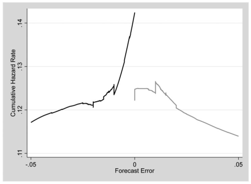

NOTE: figure/graphic rendered as an image from the PDF; its content is not machine-readable text. Caption (if any) follows as the next block.

control variables except for fiscal-quarter dummies. The coefficient of missing analyst forecasts is significantly positive that supports H1. Specifically, failing to meet analyst forecasts increases the rate of downsizing by 57%.<sup>11</sup> The effect size becomes reduced to a 40% increase but remains significant when all control variables are added in the second model.<sup>12</sup>

Most control variables show an expected association with the rate of downsizing. For instance, all measures of firm performance are negatively associated with the outcome. The results for firm-level measures of financialization are worth further discussion. Notably, firms’ reliance on financial activities is negatively associated with the rate of downsizing. While this finding seemingly contradicts the harmful effect of financialization on employment reported in previous studies, we do not think this is the case. To the extent that financial activities help improve firms’ profitability, firms may feel less pressure to adopt drastic measures, such as downsizing. In contrast, firms’ reliance on debt financing is, as expected, positively associated, suggesting that firms with high levels of debt burden are more likely to engage in downsizing.

Figure 3. Cumulative hazard rate of downsizing around zero forecast error (6$0.05). Note: The trend

line is fitted using locally weighted scatterplot smoothing.

11 The effect size is calculated as [exp(0.454) 1] 100. 12 In a test not reported in this article, we also found evidence that the effect size of missing analyst forecasts increased over time. Specifically, failing to meet analyst forecasts increased the rate of downsizing by 15% in 1984 but by 59% in 2005.

Financialization and corporate downsizing 1813

Page 20

Table 3. RD designs

[output not shown]

NOTE: table converted from PDF layout to HTML text; cell boundaries are reconstructed. See PDF if exact alignment matters.

Notes: Models include all control variables presented in Table 2 as well as fiscal-quarter fixed effects. *P < 0.05; **P < 0.001 (two-tailed tests).

Table 4. Effect of missed analyst forecasts for out-performers

[output not shown]

NOTE: table converted from PDF layout to HTML text; cell boundaries are reconstructed. See PDF if exact alignment matters.

Notes: Models include all control variables presented in Table 2 as well as fiscal-quarter fixed effects. *P < 0.05; **P < 0.01; ***P < 0.001 (two-tailed tests).

1814 J. Jung and Y. Lee

Page 21

We now turn to the interaction effects with interest group variables in Table 2. The results show that firms are more susceptible to financial market expectations in the presence of powerful shareholders and shareholder value-oriented executives. Such firms are more likely to engage in downsizing when they fail to meet such expectations. First, Model 3 in Table 2 shows a significantly positive interaction effect with institutional ownership. This result supports H2 in that firms are more likely to engage in downsizing after missing analyst forecasts when institutional investors own a sizable portion of their stock. Specifically, when institutional ownership increases from 36 to 75%,<sup>14</sup> the rate of downsizing increases from 26 to 48% when the firm fails to meet analyst forecasts. Model 4 shows a similar interaction effect with the presence of a CFO, supporting H3. For firms with a CFO, the rate of downsizing increases by 46% when the firm fails to achieve analyst forecasts, compared with the 17% increase for firms without a CFO. The results in Table 2 show the countervailing influence of labor unions. Model 5 shows a significantly negative interaction effect with industry-level union density. This result

Table 5. The effects of buy and sell recommendations by analysts

[output not shown]

NOTE: table converted from PDF layout to HTML text; cell boundaries are reconstructed. See PDF if exact alignment matters.

Notes: *P < 0.05; **P < 0.001 (two-tailed tests). Note: Models include all control variables presented in Table 2 as well as fiscal-quarter fixed effects. The models in this table cover years between 1993 and 2005 as the data on analyst recommendations from the I/B/E/S database are available from 1993 with 1 year’s lag.

13 We tested the possibility that firms proactively announced downsizing plans before releasing earnings surprise by including a lead (t þ 1) of the missing-analyst-forecasts variable. Although its coefficient was statistically significant initially, it became insignificant once a lag (t 1) of the same variable was added. These results suggest that while some firms may have preemptively announced downsizing before releasing earnings surprises, most firms did so reactively after earnings surprises. We would like to thank an anonymous reviewer for drawing our attention to the possibility of preemptive downsizing. 14 It is the range between one standard deviation below and above the mean. We use the same range for continuous moderating variables, such as analyst coverage, industry-level union density and the density of downsizing announcements.

Financialization and corporate downsizing 1815

Page 22

supports H4 in that firms in most unionized sectors are less likely to engage in downsizing even after missing analyst forecasts, compared with firms in the least unionized sectors. Specifically, when industry-level union membership increases from 6 to 35%, the percent change in the rate of downsizing after missing analyst forecasts declines from 57 to 24%. This negative interaction effect of industry-level union density remains statistically significant even when all interaction terms are simultaneously included, as shown in Model 6. This result demonstrates the possibility that the power of labor unions may ease the pressure upon firms to keep up with financial market expectations. Given the steady decline in union membership in the private sector, however, our finding seems to suggest that the resulting lack of the countervailing influence of labor gives free rein to managers when they make downsizing decisions to manage financial market expectations.

Analyst recommendations. We test an additional mechanism through which securities analysts can influence firms’ decision to downsize other than their role through quarterly earnings forecasts. In addition to offering earnings forecasts, sell-side analysts regularly issue recommendations that investors buy, hold or sell a firm’s stock (Coffee, 2006). As we explained, analysts rely on firms for the necessary information to make earnings forecasts, which can raise a question about the degree of agency analysts have in the process. In contrast, their stock recommendations are more likely to reflect their own judgments although we still cannot completely rule out firms’ influence. Hence, stock recommendations can demonstrate the role of analysts not just channeling or passively indicating expectations but also actively shaping such expectations. Our supplementary analysis, using data on analysts’ recommendations from the I/B/E/S database, shows that their sell recommendations (measured as the percentage of sell recommendations ratings among all ratings) are positively related to the rate of downsizing, while their buy recommendations are negatively related. Importantly, the effect of missing analyst forecasts remains the same even after analyst recommendations are included.

#### 7. Conclusion

In this article, we examine how the rise of financialization has contributed to the changing nature of employment relations using the case of workforce downsizing. While previous studies demonstrate how the reallocation of resources toward financial activities, at the sectoral as well as firm level, constrains employment growth (Lin and Tomaskovic-Devey, 2013; Lin, 2016), our study offers a mechanism through which the financial sector shapes downsizing decisions of non-financial firms. Our analysis using a dataset on the largest US firms shows that their downsizing decisions have become closely tied to their ability to meet expectations set by securities analysts through their quarterly earnings forecasts. When they fail, they engage in downsizing in a bid to reassure investors who closely follow analyst forecasts and firms’ performance against the benchmark. The binary indicator of whether a firm meets or fails to meet such expectations dominates other measures of corporate performance, such as whether they outperform their past performance. In this way, our study tells a story of the institutionalization of downsizing as a shareholder value strategy in the era of financialization.

By focusing on firm-level mechanisms of financialization and its impact on the changing nature of employment relations at the largest US firms, our study contributes to the literature in several ways. First, our study demonstrates an important mechanism through which the

1816 J. Jung and Y. Lee

Page 23

financial sector can exert influence over corporate employment decisions through the role of securities analysts as key financial professionals (Zuckerman, 1999; Dobbin and Zorn, 2005). One of the central aspects of financialization is the increased influence of the financial sector and its key players over non-financial firms (Tomaskovic-Devey and Lin, 2011; Appelbaum and Batt, 2014; Van der Zwan, 2014). Our study illustrates the role of financial professionals in shaping market expectations about firms and their future performance and making these expectations have material impacts on corporate decisions. Our analysis shows that the increased pressure put forth by securities analysts upon firms to meet earnings forecasts induces firms to embrace drastic restructuring measures, such as downsizing. While the original purpose of analyst forecasts was to help investors make informed decisions about firms’ prospects, in a process similar to performativity (Mackenzie and Millo, 2003), these forecasts dictate how firms should perform once market expectations are firmly formed around the forecasts. In this way, the role of securities analysts provides a powerful channel through which financial market participants can exert influence over corporate decisions to their advantage.

Second, our study draws attention to the influence of competing stakeholder groups as an important factor that can mediate the impact of financialization over firm-level employment decisions and outcomes. While many studies in organizational analysis suggest that large-scale economic, political and social changes can reshape firm behavior and strategic decisions, many other studies contend that firms do not passively yield to external changes (Westphal and Zajac, 2001; Zajac and Westphal, 2004; Goldstein, 2012; Benton 2016). A similar issue can be raised in the case of financialization. Financialization is fundamentally a political project that involves rent extraction between sectors and among actions within the firm (Tomaskovic-Devey and Lin, 2011; Lin, 2016). As such, it is a setting ripe for power struggle among stakeholder groups with competing interests. In this respect, the outcome of changing power relations among stakeholder groups and decision-making structures can significantly moderate the impact of financialization, for which our findings provide some support. In line with the growing calls for firm-level or workplace-level mechanisms of resource distribution (Tomaskovic-Devey and Avent-Holt, 2019; Tomaskovic-Devey et al., 2020), more research seems to be warranted about how the impact of financialization varies across firms and what the organizational sources are for such variation.

Overall, our study demonstrates the benefit of a more integrated approach to the research on financialization. Our investigation of the firm-level inter-group power relations helps elaborate how large national- or sector-level structural changes channel into firm-level decisions with enduring impact on corporate employment policies and practices. On the one hand, while the rise of shareholder value has been understood as part of the broader trend toward financialization, most studies on shareholder value tend to focus on the firm-level power struggle between shareholders and managers without paying closer attention to the overarching socio-economic context within which such struggle occurs (Van der Zwan, 2014; but see Davis, 2009). On the other, studies of financialization, while revealing the shift toward financial activities at the national, sectoral or firm level, often lose sight of the concrete actors and the struggle among them over financialization. As a result, it remains unclear how key players in the financial sector have exerted influence over non-financial sectors and firms. It also remains uncertain how the rise of finance has reshaped power relations among competing stakeholder groups. Our integrative approach, by exploring the consequences of the shareholder value movement in the political economic context defined by

Financialization and corporate downsizing 1817

Page 24

financialization, helps illustrate how the two forces are intimately connected and reinforce each other at different levels.

The increased influence of financial markets on corporate downsizing decisions and employment relations in general that we demonstrate in this study raises several important policy issues. First, it may explain the short-term orientation of US firms toward human resource management (Kochan, 2012; Weil, 2014). Viable human resource strategies require long-term planning and investment. The frequent use of downsizing and its responsiveness to short-term financial market expectations may make such long-term goals difficult if not impossible. It also means that finance penetrates the lives of ordinary citizens, by exposing the job security of working and middle-class citizens to the vagaries of financial markets. This trend is particularly concerning because it is unlikely that most workers can manage such risks as effectively as firms or financial institutions (Davis, 2009; Lin and Tobias Neely, 2020). The impact of the 2008 financial crisis—massive job losses and prolonged hiring freezes during the Great Recession and the jobless recovery afterward—is a drastic example that shows the broad social repercussions of financial risk (Grusky et al., 2011). But our study suggests that if financial market control over corporate employment decisions remains, the transformation of financial risks into social risks will continue.

#### Supplementary material

Supplementary material is available at Socio-Economic Review online.

#### Acknowledgements

We gratefully acknowledge thoughtful comments and helpful guidance from Editor Don Tomaskovic-Devey and the three Socio-Economic reviewers. For helpful comments, we thank Richard Benton, Frank Dobbin, Amit Kramer, Ryan Lamare, Eunmi Mun, Taekjin Shin and Shinjae Won.

#### Funding

This research was in part supported by National Science Foundation grant SES-0926934 (principal investigator Frank Dobbin).

#### References

Allison, P. D. (1995) Survival Analysis Using SAS: A Practical Guide, Cary, NC, SAS Press. Allison, P. D. (2005) Fixed Effects Regression Methods for Longitudinal Data Using SAS, Cary,

NC, SAS Press. Alvarez, I. (2015) ‘Financialization, Non-Financial Corporations and Income Inequality: The Case

of France’, Socio-Economic Review, 13, 449–475. Amihud, Y. and Lev, B. (1981) ‘Risk Reduction as a Managerial Motive for Conglomerate

Mergers’, The Bell Journal of Economics, 12, 605–617. Angrist, J. D. and Pischke, J.-S. (2009) Mostly Harmless Econometrics: An Empiricist’s

Companion, Princeton, NJ, Princeton University Press. Appelbaum, E. and Batt, R. (1994) The New American Workplace: Transforming Work Systems

in the United States, Ithaca, NY, Cornell University Press. Appelbaum, E. and Batt, R. (2014) Private Equity at Work: When Wall Street Manages Main

Street, New York, Russell Sage Foundation.

1818 J. Jung and Y. Lee

Page 25

Autor, D. H., Katz, L. F. and Kearney, M. S. (2008) ‘Trends in U.S. Wage Inequality: Revising the

Revisionists’, Review of Economics and Statistics, 90, 300–323. Bartov, E., Givoly, D. and Hayn, C. (2002) ‘The Rewards to Meeting or Beating Earnings

Expectations’, Journal of Accounting and Economics, 33, 173–204. Baumol, W. J., Blinder, A. S. and Wolff, E. N. (2003) Downsizing in America, New York, Russell

Sage Foundation. Benner, M. J. and Ranganathan, R. (2012) ‘Offsetting Illegitimacy? How Pressures from Securities

Analysts Influence Incumbents in the Face of New Technologies’, Academy of Management Journal, 55, 213–233. Benton, R. A. (2016) ‘Corporate Governance and Nested Authority: Cohesive Network Structure,

Actor-Driven Mechanisms, and the Balance of Power in American Corporations’, American Journal of Sociology, 122, 661–713. Berger, P. G. and Ofek, E. (1995) ‘Diversification’s Effect on Firm Value’, Journal of Financial

Economics, 37, 39–65. Bergstresser, D. and Philippon, T. (2006) ‘CEO Incentives and Earnings Management’, Journal of

Financial Economics, 80, 511–529. Bidwell, M. (2013) ‘What Happened to Long-Term Employment? The Role of Worker Power and

Environmental Turbulence in Explaining Declines in Worker Tenure’, Organization Science, 24, 1061–1082. Bor, J., Moscoe, E., Mutevedzi, P., Newell, M.-L. and Ba¨rnighausen T. W. (2014) ‘Regression

Discontinuity Designs in Epidemiology: Causal Inference without Randomized Trials’, Epidemiology, 25, 729–737. Box-Steffensmeier, J. M. and Jones, B. S. (2004) Event History Modeling: A Guide for Social

Scientists, Cambridge, Cambridge University Press. Budros, A. (1997) ‘The New Capitalism and Organizational Rationality: The Adoption of

Downsizing Programs, 1979’, Social Forces, 76, 229–249. Bushee, B. J. (1998) ‘The Influence of Institutional Investors on Myopic R&D Investment

Behavior’, Accounting Review, 73, 305–333. Cappelli, P. (1999) The New Deal at Work: Managing the Market-Driven Workforce, Boston,

MA, Harvard Business School Press. Carberry, E. J. and Zajac, E. J. (2020) ‘Unpacking the Dynamics of a Contested Practice: The

Case of Executive Compensation and the Shareholder Value Orientation in the USA’, Socio-Economic Review. Carleton, W. T., Nelson, J. M. and Weisbach, M. S. (1998) ‘The Influence of Institutions on

Corporate Governance through Private Negotiations: Evidence from TIAA-CREF’, The Journal of Finance, 53, 1335–1362. Cobb, J. A. (2015) ‘Risky Business: The Decline of Defined Benefit Pensions and Firms’ Shifting of

Risk’, Organization Science, 26, 1332–1350. Coffee, J. C. (2006) Gatekeepers: The Professions and Corporate Governance, New York,

Oxford University Press. Colias, M. (2005) ‘Abbott Labs’ Profit Up 38 Percent: 700 Layoffs Planned’, Associated Press

(July 13, 2005). Collingwood, H. (2001) ‘The Earnings Game’, Harvard Business Review, 79, 65–74. Darcillon, T. (2015) ‘How Does Finance Affect Labor Market Institutions? An Empirical Analysis

in 16 OECD Countries’, Socio-Economic Review, 13, 477–504. Davis, G. F. (2009) Managed by the Markets: How Finance Reshaped America, New York,

Oxford University Press. Davis, G. F. and Thompson, T. A. (1994) ‘A Social Movement Perspective on Corporate Control’,

Administrative Science Quarterly, 39, 141–173.

Financialization and corporate downsizing 1819

Page 26

Davis, G. F. and Kim, S. (2015) ‘Financialization of the Economy’, Annual Review of Sociology,

41, 203–221. Davis, L. E. (2016) ‘Identifying the “Financialization” of the Nonfinancial Corporation in the U.S.

Economy: A Decomposition of Firm-Level Balance Sheets’, Journal of Post Keynesian Economics, 39, 115–141. Dechow, P. M., Sloan, R. G. and Sweeney, A. P. (1995) ‘Detecting Earnings Management’,

Accounting Review, 70, 193–225. Degeorge, F., Patel, J. and Zeckhauser, R. (1999) ‘Earnings Management to Exceed Thresholds’,

The Journal of Business, 72, 1–33. Del Guercio, D. and Hawkins, J. (1999) ‘The Motivation and Impact of Pension Fund Activism’,

Journal of Financial Economics, 52, 293–340. Dencker, J. C. (2012) ‘Who Do Firms Lay off and Why?’, Industrial Relations: A Journal of

Economy and Society, 51, 152–169. Dobbin, F. and Zorn, D. M. (2005) ‘Corporate Malfeasance and the Myth of Shareholder Value’,

Political Power and Social Theory, 17, 179–198. Dobbin, F. and Jung, J. (2010) ‘The Misapplication of Mr. Michael Jensen: How Agency Theory

Brought down the Economy and Why It Might Again’, Research in the Sociology of Organizations, 30, 29–64. Fiss, P. C. and Zajac, E. J. (2004) ‘The Diffusion of Ideas over Contested Terrain: The

(Non)Adoption of a Shareholder Value Orientation among German Firms’, Administrative Science Quarterly, 49, 501–534. Fligstein, N. and Goldstein, A. (2015) ‘The Emergence of a Finance Culture in American

Households, 1989’, Socio-Economic Review, 13, 575–601. Fligstein, N. and Shin, T. (2007) ‘Shareholder Value and the Transformation of the American

Economy, 1984’, Sociological Forum, 22, 399–424. Flynn, L. J. (2006, May 31) ‘Sun Says It Will Cut at Least 4,000 Jobs’, New York, NY, The New

York Times. Gillan, S. L. and Starks, L. T. (2000) ‘Corporate Governance Proposals and Shareholder Activism:

The Role of Institutional Investors’, Journal of Financial Economics, 57, 275–305. Godechot, O. (2012) ‘Is Finance Responsible for the Rise in Wage Inequality in France?’,

Socio-Economic Review, 10, 447–470. Goldstein, A. (2012) ‘Revenge of the Managers: Labor Cost-Cutting and the Paradoxical

Resurgence of Managerialism in the Shareholder Value Era’, American Sociological Review, 77, 268–294. Graham, J. R., Harvey, C. R. and Rajgopal, S. (2005) ‘The Economic Implications of Corporate

Financial Reporting’, Journal of Accounting and Economics, 40, 3–73. Grusky, D. B., Western, B. and Wimer, C. (2011) The Great Recession, New York, Russell Sage

Foundation. Hacker, J. S. (2006) The Great Risk Shift: The Assault on American Jobs, Families, Health Care,

and Retirement and How You Can Fight Back, New York, Oxford University Press. Harrison, B. and Bluestone, B. (1988) The Great U-Turn: Corporate Restructuring and the

Polarizing of America, New York, Basic Books. Hirsch, B. T. and Macpherson, D. A. (2003) ‘Union Membership and Coverage Database from

the Current Population Survey: Note’, ILR Review, 56, 349–354. Jensen, M. C. (1986) ‘Agency Costs of Free Cash Flow, Corporate Finance, and Takeovers’,

American Economic Review, 76, 323–329. Jung, J. (2015) ‘Shareholder Value and Workforce Downsizing, 1981’, Social Forces, 93,

1335–1368. Jung, J. (2016) ‘Through the Contested Terrain: Implementation of Downsizing Announcements

by Large U.S. Firms’, American Sociological Review, 81, 347–373.

1820 J. Jung and Y. Lee

Page 27

Kalleberg, A. L. (2009) ‘Precarious Work, Insecure Workers: Employment Relations in

Transition’, American Sociological Review, 74, 1–22. Kaplan, S. N. and Rauh, J. (2010) ‘Wall Street and Main Street: What Contributes to the Rise in

the Highest Incomes?’, Review of Financial Studies, 23, 1004–1050. Kochan, T. A. (2012) ‘A Jobs Compact for America’s Future’, Harvard Business Review, 90,

64–72. Kochan, T. A., Katz, H. C. and McKersie, R. B. (1994) The Transformation of American

Industrial Relations, Ithaca, NY, ILR Press. Krippner, G. R. (2005) ‘The Financialization of the American Economy’, Socio-Economic Review,

3, 173–208. Lazonick, W. and O’Sullivan, M. (2000) ‘Maximizing Shareholder Value: A New Ideology for

Corporate Governance’, Economy and Society, 29, 13–35. Leicht, K. T. (1989) ‘On the Estimation of Union Threat Effects’, American Sociological Review,

54, 1035–1047. Davis, L. (2018) ‘Financialization, Shareholder Orientation and the Cash Holdings of US

Corporations’, Review of Political Economy, 30, 1–27. Lin, K.-H. (2016) ‘The Rise of Finance and Firm Employment Dynamics’, Organization Science,

27, 972–988. Lin, K.-H. and Tobias Neely, M. (2020) Divested: Inequality in the Age of Finance, New York,

Oxford University Press. Lin, K.-H. and Tomaskovic-Devey, D. (2013) ‘Financialization and U.S. Income Inequality, 1970’,

American Journal of Sociology, 118, 1284–1329. Lopez, T. J. and Rees, L. (2002) ‘The Effect of Beating and Missing Analysts’ Forecasts on the

Information Content of Unexpected Earnings’, Journal of Accounting, Auditing & Finance, 17, 155–184. Love, E. G. and Nohria, N. (2005) ‘Reducing Slack: The Performance Consequences of

Downsizing by Large Industrial Firms, 1977’, Strategic Management Journal, 26, 1087–1108. Mackenzie, D. and Millo, Y. (2003) ‘Constructing a Market, Performing Theory: The Historical

Sociology of a Financial Derivatives Exchange’, American Journal of Sociology, 109, 107–145. Martin, A. W. and Dixon, M. (2010) ‘Changing to Win? Threat, Resistance, and the Role of

Unions in Strikes, 1984’, American Journal of Sociology, 116, 93–129. Mazmanian, M. and Beckman, C. M. (2018) ‘Making” Your Numbers: Engendering Organizational Control through a Ritual of Quantification’, Organization Science, 29, 357–379. Meyer, B. (2019) ‘Financialization, Technological Change, and Trade Union Decline’, Socio-Economic Review, 17, 477–502. Mizruchi, M. S. (1983) ‘Who Controls Whom? An Examination of the Relation between

Management and Boards of Directors in Large American Corporations’, Academy of Management Review, 8, 426–435. Orhangazi, O<sup>¨</sup>. (2008) ‘Financialisation and Capital Accumulation in the Non-Financial Corporate

Sector: A Theoretical and Empirical Investigation on the US Economy: 1973-2003’, Cambridge Journal of Economics, 32, 863–886. Osterman, P. (1999) Securing Prosperity: The American Labor Market: How It Has Changed and

What to Do about It, Princeton, NJ, Princeton University Press. Palepu, K. (1985) ‘Diversification Strategy, Profit Performance and the Entropy Measure’,

Strategic Management Journal, 6, 239–255. Parrino, R., Sias, R. W. and Starks, L. T. (2003) ‘Voting with Their Feet: Institutional Ownership

Changes around Forced CEO Turnover’, Journal of Financial Economics, 68, 3–46. Pernell, K., Jung, J. and Dobbin, F. (2017) ‘The Hazards of Expert Control: Chief Risk Officers

and Risky Derivatives’, American Sociological Review, 82, 511–541.

Financialization and corporate downsizing 1821

Page 28

Philippon, T. and Reshef, A. (2012) ‘Wages and Human Capital in the U.S. Finance Industry:

1909’, The Quarterly Journal of Economics, 127, 1551–1609. Puffer, S. M. and Weintrop, J. B. (1991) ‘Corporate Performance and CEO Turnover: The Role of

Performance Expectations’, Administrative Science Quarterly, 36, 1–19. Roberts, A. and Kwon, R. (2017) ‘Finance, Inequality and the Varieties of Capitalism in

Post-Industrial Democracies’, Socio-Economic Review, 15, 511–538. Rosenfeld, J. (2006) ‘Desperate Measures: Strikes and Wages in Post-Accord America’, Social

Forces, 85, 235–265. Sauder, M. and Espeland, W. N. (2009) ‘The Discipline of Rankings: Tight Coupling and

Organizational Change’, American Sociological Review, 74, 63–82. Shin, T. (2013) ‘The Shareholder Value Principle: The Governance and Control of Corporations

in the United States’, Sociology Compass, 7, 829–840. Shin, T. (2014) ‘Explaining Pay Disparities between Top Executives and Nonexecutive

Employees: A Relative Bargaining Power Approach’, Social Forces, 92, 1339–1372. Singer, J. D. and Willett, J. B. (2003) Applied Longitudinal Data Analysis: Modeling Change and

Event Occurrence, New York, Oxford University Press. Sørensen, A. B. (2000) ‘Toward a Sounder Basis for Class Analysis’, American Journal of

Sociology, 105, 1523–1558. Stiglitz, J. E. (2012) The Price of Inequality: How Today’s Divided Society Endangers Our

Future, New York, W.W. Norton. Tomaskovic-Devey, D. and Avent-Holt, D. (2019) Relational Inequalities: An Organizational

Approach, New York, Oxford University Press. Tomaskovic-Devey, D. and Lin, K.-H. (2011) ‘Income Dynamics, Economic Rents, and the

Financialization of the U.S’, American Sociological Review, 76, 538–559. Tomaskovic-Devey, D., Lin, K.-H. and Meyers, N. (2015) ‘Did Financialization Reduce Economic

Growth?’, Socio-Economic Review, 13, 525–548. Tomaskovic-Devey, D., Rainey A., Avent-Holt, D., Bandelj, N., Boza, I., Cort, D., Godechot, O.,

Hajdu, G., Ha¨llsten, M., Henriksen, L. F., Hermansen, A. S., Hou, F., Jung, J., Kanjuo-Mrcela, A., King, J., Kodama, N., Kristal, T., Krı´zkova´, A., Lippe´nyi, Z., Melzer, S. M., Mun, E., Penner, A., Petersen, T., Poje, A., Safi, M., Thaning, M. and Tufail, Z. (2020) ‘Rising between-Workplace Inequalities in High-Income Countries’, Proceedings of the National Academy of Sciences of the United States of America, 117, 9277–9283. Tori, D. and Onaran, O<sup>¨</sup>. (2020) ‘Financialization, Financial Development and Investment.

Evidence from European Non-Financial Corporations’, Socio-Economic Review, 18, 681–718. Useem, M. (1996) Investor Capitalism: How Money Managers Are Changing the Face of

Corporate America, New York, Basic Books. Van der Zwan, N. (2014) ‘Making Sense of Financialization’, Socio-Economic Review, 12,

99–129. Washburn, M. and Bromiley, P. (2014) ‘Managers and Analysts: An Examination of Mutual

Influence’, Academy of Management Journal, 57, 849–868. Weil, D. (2014) The Fissured Workplace: Why Work Became So Bad for so Many and What Can

Be Done to Improve It, Cambridge, MA, Harvard University Press. Westphal, J. D. and Zajac, E. J. (2001) ‘Decoupling Policy from Practice: The Case of Stock

Repurchase Programs’, Administrative Science Quarterly, 46, 202–228. Zajac, E. J. and Westphal, J. D. (2004) ‘The Social Construction of Market Value:

Institutionalization and Learning Perspectives on Stock Market Reactions’, American Sociological Review, 69, 433–457. Zhang, X., Bartol, K. M., Smith, K. G., Pfarrer, M.D. and Khanin, D. M. (2008) ‘CEOs on the

Edge: Earnings Manipulation and Stock-Based Incentive Misalignment’, Academy of Management Journal, 51, 241–258.

1822 J. Jung and Y. Lee

Page 29

Zhang, Y. and Gimeno, J. (2010) ‘Earnings Pressure and Competitive Behavior: Evidence from the

U.S. Electricity Industry’, Academy of Management Journal, 53, 743–768. Zorn, D. M. (2004) ‘Here a Chief, There a Chief: The Rise of the CFO in the American Firm’,

American Sociological Review, 69, 345–364. Zuckerman, E. W. (1999) ‘The Categorical Imperative: Securities Analysts and the Illegitimacy

Discount’, American Journal of Sociology, 104, 1398–1438. Zuckerman, E. W. (2000) ‘Focusing the Corporate Product: Securities Analysts and De-Diversification’, Administrative Science Quarterly, 45, 591–619.

Financialization and corporate downsizing 1823